# Project_2

Maxim Serdakov

11/30/2020

# 1 Обязательная часть

## 1.1 Задание 1. Построение полной линейной модели.

Сначала откроем данные и кратко посмотрим на них.

```r
data <- Boston
str(data)
```

```
## 'data.frame':    506 obs. of  14 variables:
##  $ crim   : num  0.00632 0.02731 0.02729 0.03237 0.06905 ...
##  $ zn     : num  18 0 0 0 0 0 12.5 12.5 12.5 12.5 ...
##  $ indus  : num  2.31 7.07 7.07 2.18 2.18 2.18 7.87 7.87 7.87 7.87 ...
##  $ chas   : int  0 0 0 0 0 0 0 0 0 0 ...
##  $ nox    : num  0.538 0.469 0.469 0.458 0.458 0.458 0.524 0.524 0.524 0.524 ...
##  $ rm     : num  6.58 6.42 7.18 7 7.15 ...
##  $ age    : num  65.2 78.9 61.1 45.8 54.2 58.7 66.6 96.1 100 85.9 ...
##  $ dis    : num  4.09 4.97 4.97 6.06 6.06 ...
##  $ rad    : int  1 2 2 3 3 3 5 5 5 5 ...
##  $ tax    : num  296 242 242 222 222 222 311 311 311 311 ...
##  $ ptratio: num  15.3 17.8 17.8 18.7 18.7 18.7 15.2 15.2 15.2 15.2 ...
##  $ black  : num  397 397 393 395 397 ...
##  $ lstat  : num  4.98 9.14 4.03 2.94 5.33 ...
##  $ medv   : num  24 21.6 34.7 33.4 36.2 28.7 22.9 27.1 16.5 18.9 ...
```

Заметим, что в данном случае все переменные численные кроме двух - это переменные chas, которая принимает только значения 0 и 1, а так же явно факторная переменная rad. В дальнейшем нам необходимо будет сравнить между собой коэффииценты между разными предикторами в модели. Но, так как стандартизация факторных переменных не имеет никакого смысла, проведем стандартизацию всех переменных, кроме этих двух. Заодно превратим их в непосредственно факторные.

```r
data_scale <- as.data.frame(sapply(data, scale))
data_scale$chas <- as.factor(data$chas)
data_scale$rad <- as.factor(data$rad)
```

Теперь, для стандартизированного датасета построим полную линейную модель без учета взаимодействия предикторов.

```r
mod_scale <- lm(medv ~ ., data = data_scale)
summary(mod_scale)
```

```
##
## Call:
## lm(formula = medv ~ ., data = data_scale)
##
## Residuals:
##      Min       1Q   Median       3Q      Max
## -1.64204 -0.29743 -0.04963  0.18289  2.82100
##
## Coefficients:
##              Estimate Std. Error t value Pr(>|t|)
## (Intercept) -0.458954   0.125554  -3.655 0.000285 ***
## crim        -0.101774   0.030569  -3.329 0.000937 ***
## zn           0.139209   0.035880   3.880 0.000119 ***
## indus        0.017723   0.047476   0.373 0.709081
## chas1        0.274452   0.093854   2.924 0.003614 **
## nox         -0.221410   0.049092  -4.510 8.13e-06 ***
## rm           0.280027   0.032177   8.703  < 2e-16 ***
## age          0.001411   0.040482   0.035 0.972210
## dis         -0.355919   0.046228  -7.699 7.75e-14 ***
## rad2         0.161888   0.160649   1.008 0.314095
## rad3         0.508992   0.145187   3.506 0.000498 ***
## rad4         0.280114   0.129102   2.170 0.030514 *
## rad5         0.317327   0.131303   2.417 0.016028 *
## rad6         0.128936   0.159182   0.810 0.418342
## rad7         0.530492   0.170836   3.105 0.002012 **
## rad8         0.526235   0.162188   3.245 0.001257 **
## rad24        0.811307   0.194483   4.172 3.58e-05 ***
## tax         -0.160310   0.071371  -2.246 0.025144 *
## ptratio     -0.228902   0.034009  -6.731 4.78e-11 ***
## black        0.093247   0.026411   3.531 0.000454 ***
## lstat       -0.410916   0.039319 -10.451  < 2e-16 ***
## ---
## Signif. codes:  0 '***' 0.001 '**' 0.01 '*' 0.05 '.' 0.1 ' ' 1
##
## Residual standard error: 0.5103 on 485 degrees of freedom
## Multiple R-squared:  0.7499, Adjusted R-squared:  0.7396
## F-statistic:  72.7 on 20 and 485 DF,  p-value: < 2.2e-16
```

## 1.2 Задание 2. Диагностика полной линейной модели.

Проведем диагностику данной модели на основании следующих условий: а. Проверка линейности взаимосвязи б. Проверка влиятельных наблюдений в. Независимость наблюдений г. Нормальность распределения и постоянство дисперсии

Произведем необходимый анализ с помощью функции fortify() из пакета ggplot.

```r
mod_diag <- fortify(mod_scale)
head(mod_diag)
```

```
##         medv       crim         zn      indus chas        nox        rm
## 1  0.1595278 -0.4193669  0.2845483 -1.2866362    0 -0.1440749 0.4132629
## 2 -0.1014239 -0.4169267 -0.4872402 -0.5927944    0 -0.7395304 0.1940824
## 3  1.3229375 -0.4169290 -0.4872402 -0.5927944    0 -0.7395304 1.2814456
## 4  1.1815886 -0.4163384 -0.4872402 -1.3055857    0 -0.8344581 1.0152978
## 5  1.4860323 -0.4120741 -0.4872402 -1.3055857    0 -0.8344581 1.2273620
## 6  0.6705582 -0.4166314 -0.4872402 -1.3055857    0 -0.8344581 0.2068916
##          age      dis rad        tax    ptratio     black      lstat       .hat
## 1 -0.1198948 0.140075   1 -0.6659492 -1.4575580 0.4406159 -1.0744990 0.06791883
## 2  0.3668034 0.556609   2 -0.9863534 -0.3027945 0.4406159 -0.4919525 0.05142703
## 3 -0.2655490 0.556609   2 -0.9863534 -0.3027945 0.3960351 -1.2075324 0.05219742
## 4 -0.8090878 1.076671   3 -1.1050216  0.1129203 0.4157514 -1.3601708 0.03641124
## 5 -0.5106743 1.076671   3 -1.1050216  0.1129203 0.4406159 -1.0254866 0.03691210
## 6 -0.3508100 1.076671   3 -1.1050216  0.1129203 0.4101651 -1.0422909 0.03578377
##      .sigma      .cooksd   .fitted     .resid  .stdresid
## 1 0.5104050 0.0030458502 0.6211457 -0.4616179 -0.9369052
## 2 0.5107238 0.0007043697 0.1582003 -0.2596242 -0.5223356
## 3 0.5101708 0.0034668073 0.7516851  0.5712523  1.1497646
## 4 0.5106156 0.0008605582 0.8351440  0.3464447  0.6915569
## 5 0.5097574 0.0038427199 0.7593063  0.7267260  1.4510341
## 6 0.5107900 0.0002601103 0.4783022  0.1922560  0.3836477
```

### 1.2.1 Проверка независимости наблюдений.

```r
durbinWatsonTest(mod_scale)
```

```
##  lag Autocorrelation D-W Statistic p-value
##    1       0.4512223      1.089005       0
##  Alternative hypothesis: rho != 0
```

В данном случае значение критерия Дарбина-Уотсона меньше 2, то есть присутствует положительная автокорреляция. Значит, мы не можем сказать, что наблюдения в данном случае независимые.

### 1.2.2 Проверка линейности взаимодействий и постоянства дисперсии. График остатков модели от предсказанных значений.

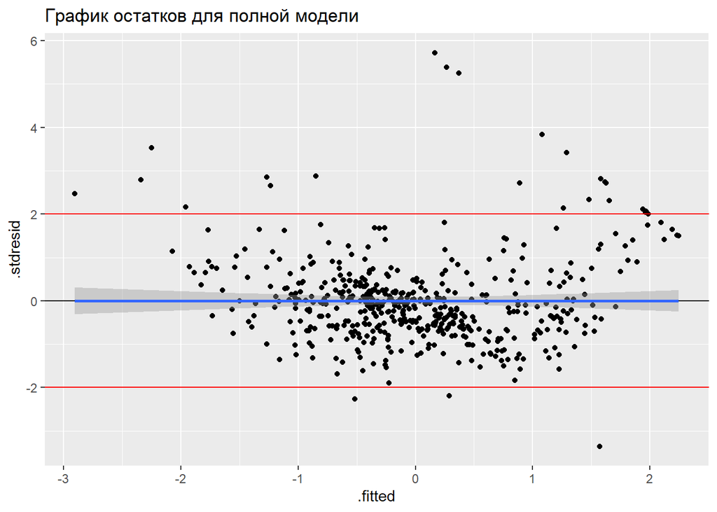

```r
gg_resid <- ggplot(data = mod_diag, aes(x = .fitted, y = .stdresid)) +
  geom_point() +
  geom_hline(yintercept = 0)+
  geom_smooth(method = "lm") +
  geom_hline(yintercept = 2, color = "red") +
  geom_hline(yintercept = -2, color = "red") +
  ggtitle("График остатков для полной модели")

gg_resid
```

Гетероскедактичности не обнаружено, то есть с дисперсиями все хорошо. Однако, есть большие проблемы с линейностью взимосвязи для корректности данной модели - довольно много точек на этом графике выбивается за пределы в +/- 2 стандартных отклонения. В начале и в конце есть большое количество положительных по этому фактору значений.

### 1.2.3 Проверка влиятельных наблюдений. График расстояний Кука.

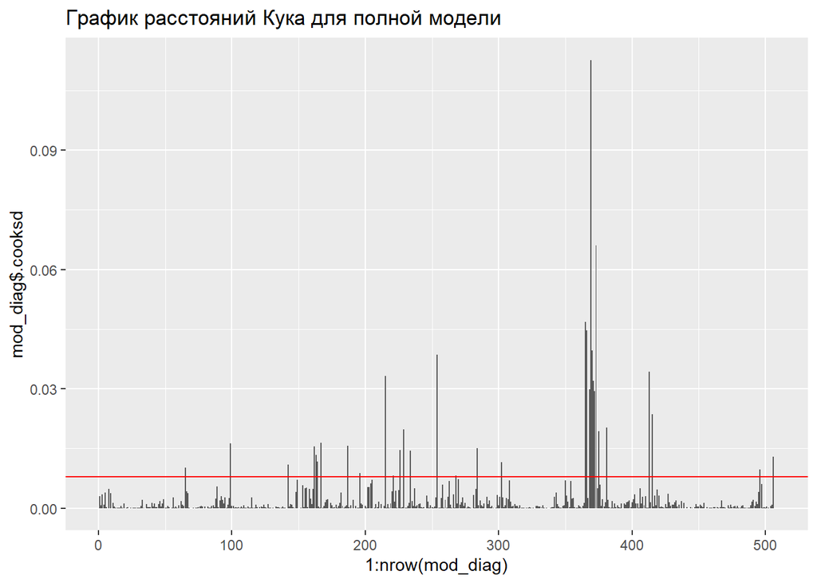

```r
ggplot(, aes(x = 1:nrow(mod_diag), y = mod_diag$.cooksd)) +
  geom_bar(stat = "identity")+
  geom_hline(yintercept = 4/nrow(data_scale), color = "red")+
  ggtitle("График расстояний Кука для полной модели")
```

Верхняя граница была посчитана по формуле из https://imaging.mrc-cbu.cam.ac.uk/statswiki/FAQ/RegressionOutliers. Видим, что немалое число наблюдений выбиваются за линию. Соответственно, в данных имеется немалое число выбросов.

### 1.2.4 Проверка на нормальность распеределения. График QQ-plot.

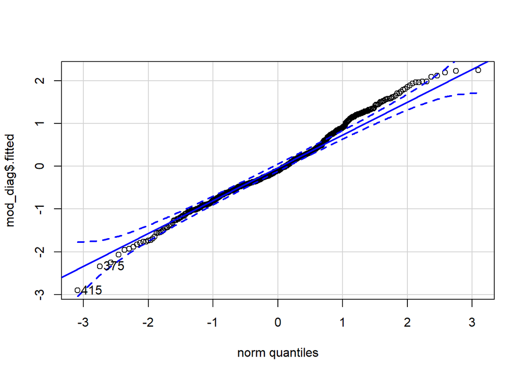

```
## [1] 415 375
```

```r
qqPlot(mod_diag$.fitted)
```

Как итог, полная модель не является корректной, так как:

- наблюдаются проблемы с наличием влиятельных наблюдений;
- зависимости часто не являются линейными;
- распределение для значений всех предикторов не является нормальным;
- многие предикторы зависимы друг от друга, то есть имеются проблемы с мультиколлениарностью.

Соответственно, в дополнительной части работы мы будем пытаться оптимизировать модель для более точных предсказаний.

## 1.3 Задание 3. График предсказания стоимости от переменной с наибольшим коэффициентом.

Еще раз посмотрим на коэффициенты нашей модели.

```r
summary(mod_scale)
```

```
##
## Call:
## lm(formula = medv ~ ., data = data_scale)
##
## Residuals:
##      Min       1Q   Median       3Q      Max
## -1.64204 -0.29743 -0.04963  0.18289  2.82100
##
## Coefficients:
##              Estimate Std. Error t value Pr(>|t|)
## (Intercept) -0.458954   0.125554  -3.655 0.000285 ***
## crim        -0.101774   0.030569  -3.329 0.000937 ***
## zn           0.139209   0.035880   3.880 0.000119 ***
## indus        0.017723   0.047476   0.373 0.709081
## chas1        0.274452   0.093854   2.924 0.003614 **
## nox         -0.221410   0.049092  -4.510 8.13e-06 ***
## rm           0.280027   0.032177   8.703  < 2e-16 ***
## age          0.001411   0.040482   0.035 0.972210
## dis         -0.355919   0.046228  -7.699 7.75e-14 ***
## rad2         0.161888   0.160649   1.008 0.314095
## rad3         0.508992   0.145187   3.506 0.000498 ***
## rad4         0.280114   0.129102   2.170 0.030514 *
## rad5         0.317327   0.131303   2.417 0.016028 *
## rad6         0.128936   0.159182   0.810 0.418342
## rad7         0.530492   0.170836   3.105 0.002012 **
## rad8         0.526235   0.162188   3.245 0.001257 **
## rad24        0.811307   0.194483   4.172 3.58e-05 ***
## tax         -0.160310   0.071371  -2.246 0.025144 *
## ptratio     -0.228902   0.034009  -6.731 4.78e-11 ***
## black        0.093247   0.026411   3.531 0.000454 ***
## lstat       -0.410916   0.039319 -10.451  < 2e-16 ***
## ---
## Signif. codes:  0 '***' 0.001 '**' 0.01 '*' 0.05 '.' 0.1 ' ' 1
##
## Residual standard error: 0.5103 on 485 degrees of freedom
## Multiple R-squared:  0.7499, Adjusted R-squared:  0.7396
## F-statistic:  72.7 on 20 and 485 DF,  p-value: < 2.2e-16
```

Увидим, что наибольший из них по модулю - это коэффициент перед уровнем фактора rad, а точнее перед rad24. Это можно интепретировать как то, что наибольший вклад вносит эта факторная переменная - то есть самой большей стоимостью при прочих равных обладают дома, которые имеют 24-часовой доступ к круговым автомагистралям. Однако, не совсем ясно, как делать предсказание для факторной переменной, каким будет обладать смыслом такое предсказание зависимой переменной - ведь если значения для rad = 10 нет, то значит таких домов вероятнее всего не существует. А значит, не имеет практического смысла предсказывать medv для rad=10. Поэтому, сделаем так - построим график предсказания зависимой переменной на основе численной переменной с наибольшим по модулю коэффициентом - это переменная lstat. Но, чтобы учесть важность факторной переменной rad - сделаем это предсказание отдельно для каждого из уровней фактора. Тогда мы по умолчанию предполагаем важность rad - эта переменная учитывается первой, и уже разбив по ней мы предсказываем стоимость в зависимости от значений зависимой переменной со следующим наибольшим по модулю коэффициентом.

Сначала сделаем искуственный датасет для предсказывания результатов.

```r
MyData <- data.frame(
    rad = data_scale$rad,
    chas = data_scale$chas,
    crim = mean(data_scale$crim),
     zn = mean(data_scale$zn),
     nox = mean(data_scale$nox),
     rm = mean(data_scale$rm),
     age = mean(data_scale$age),
     dis = mean(data_scale$dis),
     tax = mean(data_scale$tax),
     ptratio = mean(data_scale$ptratio),
     black = mean(data_scale$black),
     lstat = seq(min(data_scale$lstat), max(data_scale$lstat),length.out = nrow(data_scale)),
     indus = mean(data_scale$indus))
Predictions <- predict(mod_scale, newdata = MyData,  interval = 'confidence')
data_predicted <- data.frame(MyData, Predictions)
```

Теперь построим график для результатов предсказаний.

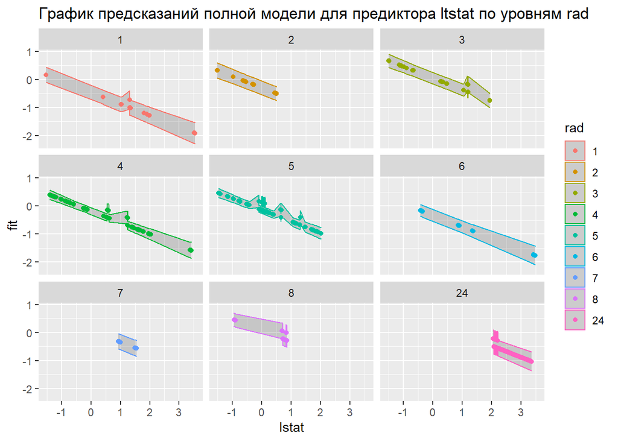

```r
graph_of_predict <- ggplot(data_predicted, aes(x = lstat, y = fit, color = rad)) +
  geom_ribbon(alpha = 0.2, aes(ymin = lwr, ymax = upr)) +
  geom_point() +
  ggtitle("График предсказаний полной модели для предиктора ltstat по уровням rad")+
  facet_wrap(~rad)
graph_of_predict
```